# KOI analysis - Data preparation

Davide Tonetto

13 May, 2025

# 1 Data description - Kepler Objects of Interest (KOIs)

KOIs are well-vetted, periodic, transit-like events in the Kepler data. The Kepler Project identifies these objects from the TCE list for further vetting. Some objects will be flagged as false positives.

All KOI tables are displayed in a single, interactive environment with separate tabs for each table (e.g., Q1-6, Q1-8, cumulative, etc). Column selection and filtering apply to all tabs, allowing easier comparison of values across KOI tables.

## 1.1 Dataset Selection and Characteristics

The dataset selected for this statistical analysis aimed at predicting exoplanet status is the Q1-Q17 Data Release 25 (DR 25) Kepler Objects of Interest (KOI) table. This specific table was chosen due to several key characteristics that make it particularly well-suited for developing robust statistical models:

1. **Uniform Data Processing**: The table is derived from Data Release 25, which represents the final, uniform processing of the entire primary Kepler mission dataset (Quarters 1 through 17). This ensures consistency in the underlying light curve data used for analysis.
2. **Automated and Uniform Vetting**: A critical feature of the DR 25 KOI table is its use of a fully automated dispositioning process, known as the Kepler Robovetter. This algorithm applies a consistent set of rules and metrics to uniformly classify each Threshold Crossing Event (TCE) as either a Planetary Candidate (PC) or a False Positive (FP).
3. **Designed for Statistical Analysis**: As explicitly stated in its documentation, this catalog was generated with the primary goal of enabling statistical analyses, such as the calculation of exoplanetary occurrence rates. The emphasis was placed on uniformity and automated, repeatable classification rather than maximizing the accuracy for every single individual object (which might involve manual intervention or external data, as seen in the DR25 Supplemental table).
4. **Homogeneity**: The automated and uniform vetting process yields a homogenous catalog suitable for robust statistical analyses. This internal consistency is crucial for training reliable statistical or machine learning models, as the classification criteria are applied consistently across all entries designated as KOIs within this table.

Therefore, the Q1-Q17 DR 25 KOI table was selected because its **rigorous, automated, and uniform classification methodology provides the most suitable foundation for building a statistical model** intended to predict whether an object is likely an exoplanet based on the parameters derived consistently from the Kepler pipeline and vetting process. This minimizes biases that could arise from aggregating data processed or vetted using different methods over time, as found in the Cumulative table, or from incorporating non-uniform manual assessments, as in the Supplemental table.

## 1.2 Columns Description

### 1.2.1 Identification Columns

Basic identifiers linking the Kepler Object of Interest (KOI) to the target star in the Kepler Input Catalog (KIC).

- **`kepid`**: Kepler Identification (KepID) - Target identification number from the Kepler Input Catalog (KIC). Unique per target.
- **`kepoi_name`**: KOI Name - Unique identifier for a Kepler Object of Interest (KOI), format KNNNNN.DD. The integer part identifies the target star, the decimal part identifies the specific transiting object.

### 1.2.2 Exoplanet Archive Information

Status and naming conventions are maintained by the NASA Exoplanet Archive, reflecting the official disposition and vetting status.

- **`kepler_name`**: Kepler Name - Official name (“Kepler-Nn”) assigned to confirmed or validated planets.
- **`koi_disposition`**: Exoplanet Archive Disposition - The classification status of the KOI within the Exoplanet Archive (e.g., CANDIDATE, FALSE POSITIVE, CONFIRMED, NOT DISPOSITIONED).
- **`koi_vet_stat`**: Vetting Status - The status of the vetting process for this KOI delivery (ACTIVE or DONE). Critical for sample completeness studies.
- **`koi_vet_date`**: Date of Last Parameter Update - The date when parameters for this KOI were last updated.

### 1.2.3 Project Disposition Columns

Columns detailing the classification (Candidate, False Positive) determined by the Kepler project’s automated vetting pipeline (Robovetter), including confidence scores and specific false positive flags.

- **`koi_pdisposition`**: Disposition Using Kepler Data - Pipeline flag indicating the most probable physical explanation (CANDIDATE, FALSE POSITIVE, NOT DISPOSITIONED). Based on Kepler data analysis.
- **`koi_score`**: Disposition Score - A value (0-1) indicating confidence in the `koi_pdisposition`. Higher score means more confidence for CANDIDATEs, less confidence for FALSE POSITIVEs.
- **`koi_fpflag_nt`**: Not Transit-Like Flag - Set if the light curve is inconsistent with a transiting planet model (e.g., instrumental artifact, stellar variability).
- **`koi_fpflag_ss`**: Stellar Eclipse Flag - Set if a significant secondary event, transit shape, or variability suggests an eclipsing binary. Can also be set for self-luminous hot Jupiters (still dispositioned as PC).
- **`koi_fpflag_co`**: Centroid Offset Flag - Set if the transit signal likely originates from a nearby star, indicated by centroid shifts or halo pixel signals.
- **`koi_fpflag_ec`**: Ephemeris Match Indicates Contamination Flag - Set if the KOI shares period/epoch with another object, suggesting contamination.
- **`koi_disp_prov`**: Disposition Provenance - Indicates the source or basis for the object’s disposition.
- **`koi_comment`**: KOI Comment - Text description explaining the reason for a FALSE POSITIVE disposition or listing minor Robovetter flags.

### 1.2.4 Transit Properties

Parameters describing the observed transit event itself, derived from light curve fitting (e.g., period, duration, depth) and related physical properties of the planet candidate (e.g., radius, temperature).

- **`koi_period`**: Orbital Period (days) - The time interval between consecutive transits.
- **`koi_time0bk`**: Transit Epoch (BJD - 2,454,833.0) - Time corresponding to the center of the first detected transit in Barycentric Julian Day, minus a constant offset (Jan 1, 2009 12:00 UTC).
- **`koi_time0`**: Transit Epoch in BJD - Time corresponding to the center of the first detected transit in Barycentric Julian Day (BJD).
- **`koi_eccen`**: Eccentricity - Orbital eccentricity value.
- **`koi_longp`**: Longitude of Periastron (deg) - Orbital longitude of periastron.
- **`koi_impact`**: Impact Parameter - Sky-projected distance between star center and planet center at conjunction, normalized by stellar radius.
- **`koi_duration`**: Transit Duration (hours) - Time from first contact to last contact of the transit.
- **`koi_ingress`**: Ingress Duration (hours) - Time between first and second contact during the transit.
- **`koi_depth`**: Transit Depth (parts per million) - Fraction of stellar flux lost at the minimum of the transit.
- **`koi_ror`**: Planet-Star Radius Ratio - The ratio of the planet’s radius to the star’s radius.
- **`koi_srho`**: Fitted Stellar Density (g/cm³) - Stellar density derived directly from light curve fitting (period, depth, duration), independent of listed stellar mass/radius.
- **`koi_fittype`**: Planetary Fit Type - Method used to fit planetary parameters (e.g., LS, MCMC, DV).
- **`koi_prad`**: Planetary Radius (Earth radii) - Radius of the planet, derived from `koi_ror` and `koi_srad`.
- **`koi_sma`**: Orbit Semi-Major Axis (AU) - Half of the long axis of the planet’s orbit, derived using Kepler’s third law.
- **`koi_incl`**: Inclination (deg) - Angle between the orbital plane and the plane of the sky.
- **`koi_teq`**: Equilibrium Temperature (Kelvin) - Estimated temperature of the planet assuming blackbody radiation, Bond albedo of 0.3, and even heat distribution.
- **`koi_insol`**: Insolation Flux (Earth flux) - Incident stellar flux on the planet relative to the flux received by Earth from the Sun.
- **`koi_dor`**: Planet-Star Distance over Star Radius - Distance between planet and star at mid-transit, normalized by stellar radius.
- **`koi_limbdark_mod`**: Limb Darkening Model Name - Reference to the limb-darkening model used.
- **`koi_ldm_coeff1`, `koi_ldm_coeff2`, `koi_ldm_coeff3`, `koi_ldm_coeff4`**: Limb Darkening Coefficients - Up to four coefficients defining the stellar limb darkening profile used in the transit fit.
- **`koi_parm_prov`**: KOI Parameter Provenance - Indicates the source or method used to derive the KOI parameters.

### 1.2.5 Threshold-Crossing Event (TCE) Information

Details about the initial detection signal (TCE) from the Transiting Planet Search (TPS) pipeline that led to the KOI designation, including signal strength metrics and data links.

- **`koi_max_sngle_ev`**: Maximum Single Event Statistic - Maximum statistical significance (SES) of an individual transit event in the light curve.
- **`koi_max_mult_ev`**: Maximum Multiple Event Statistic - Maximum signal-to-noise ratio (MES) found when folding the light curve at trial periods; threshold determines TCE identification.
- **`koi_model_snr`**: Transit Signal-to-Noise - Transit depth normalized by the mean flux uncertainty during transits.
- **`koi_count`**: Number of Planets - Number of planet candidates identified in this system.
- **`koi_num_transits`**: Number of Transits - Number of expected or partially observed transits within the searched light curve (excluding those fully in gaps).
- **`koi_tce_plnt_num`**: TCE Planet Number - The planet number assigned within the corresponding TCE delivery.
- **`koi_tce_delivname`**: TCE Delivery Name - Identifier for the TCE delivery from which this KOI’s data originates.
- **`koi_quarters`**: Quarters - Bit string indicating which Kepler quarters were included in the transit search for this KOI.
- **`koi_trans_mod`**: Transit Model Name - Reference to the transit model used for fitting (e.g., Mandel-Agol).
- **`koi_model_dof`**: Model Degrees of Freedom (DOF) - Number of degrees of freedom in the transit model fit.
- **`koi_model_chisq`**: Model Goodness of Fit - Chi-squared (χ²) or reduced chi-squared statistic for the transit model fit.
- **`koi_datalink_dvr`**: Link to DV Report - Relative path for retrieving the detailed Data Validation report.
- **`koi_datalink_dvs`**: Link to DV Summary - Relative path for retrieving the Data Validation summary report.

### 1.2.6 Stellar Parameters

Physical properties of the host star (e.g., temperature, radius, mass, metallicity, age), crucial for deriving accurate planetary parameters and understanding the system context.

- **`koi_steff`**: Stellar Effective Temperature (Kelvin) - Photospheric temperature of the host star.
- **`koi_slogg`**: Stellar Surface Gravity (log10(cm s⁻²)) - Logarithm (base-10) of the gravitational acceleration at the star’s surface.
- **`koi_smet`**: Stellar Metallicity ([Fe/H]) - Logarithm (base-10) of the Iron-to-Hydrogen ratio relative to the Sun.
- **`koi_srad`**: Stellar Radius (solar radii) - Photospheric radius of the host star.
- **`koi_smass`**: Stellar Mass (solar mass) - Mass of the host star.
- **`koi_sage`**: Stellar Age (Gigayears) - Age of the host star.
- **`koi_sparprov`**: Provenance of Stellar Parameters - Flag indicating the source/method used to determine the stellar parameters (e.g., KIC, SME, SPC, Astero).

### 1.2.7 KIC Parameters

Positional and photometric data for the target star as originally listed in the Kepler Input Catalog (KIC), including magnitudes in various bands.

- **`ra`**: RA (deg) - KIC Right Ascension in decimal degrees.
- **`dec`**: Dec (deg) - KIC Declination in decimal degrees.
- **`koi_kepmag`**: Kepler-band (mag) - Apparent magnitude in the Kepler bandpass.
- **`koi_gmag`**: KIC g’-band mag - Apparent magnitude in g’-band from the KIC.
- **`koi_rmag`**: KIC r’-band mag - Apparent magnitude in r’-band from the KIC.
- **`koi_imag`**: KIC i’-band mag - Apparent magnitude in i’-band from the KIC.
- **`koi_zmag`**: KIC z’-band mag - Apparent magnitude in z’-band from the KIC.
- **`koi_jmag`**: KIC J-band mag - Apparent magnitude in J-band from 2MASS survey.
- **`koi_hmag`**: KIC H-band mag - Apparent magnitude in H-band from 2MASS survey.
- **`koi_kmag`**: KIC K-band mag - Apparent magnitude in K-band from 2MASS survey.

### 1.2.8 Pixel-Based KOI Vetting Statistics

Two pixel analysis methods, flux-weighted centroid and PRF-fit difference images, are used to identify eclipsing binaries causing planetary transit false positives. These methods estimate the source location of the transit signal and compare it to the Kepler Input Catalog (KIC) target star position. For saturated stars, manual inspection of data validation reports is necessary.

- **`koi_fwm_sra`**: FW Source α(OOT) (hours) - Right Ascension (J2000) of the transiting object location calculated from flux-weighted centroids. Affected by crowding.
- **`koi_fwm_sdec`**: FW Source δ(OOT) (degrees) - Declination (J2000) of the transiting object location calculated from flux-weighted centroids. Affected by crowding.
- **`koi_fwm_srao`**: FW Δα(OOT) (seconds time) - RA (J2000) flux-weighted centroid shift (In-Transit - Out-Of-Transit).
- **`koi_fwm_sdeco`**: FW Δδ(OOT) (arcseconds) - Dec (J2000) flux-weighted centroid shift (In-Transit - Out-Of-Transit).
- **`koi_fwm_prao`**: FW Source Δα(OOT) (seconds time) - Calculated RA offset of the transiting object from the KIC target star location (flux-weighted). Accuracy degrades if source flux falls outside aperture.
- **`koi_fwm_pdeco`**: FW Source Δδ(OOT) (arcseconds) - Calculated Dec offset of the transiting object from the KIC target star location (flux-weighted). Accuracy degrades if source flux falls outside aperture.
- **`koi_fwm_stat_sig`**: Flux-Weighted Offset Significance (%) - Statistical significance of the flux-weighted offset. 100% indicates no significant offset (transit likely on target). Accuracy degrades if source flux falls outside aperture.
- **`koi_dicco_mra`**: PRF ΔαSQ(OOT) (arcseconds) - Mean angular offset in RA between PRF centroids (Difference Image - OOT Image), averaged over quarters.
- **`koi_dicco_mdec`**: PRF ΔδSQ(OOT) (arcseconds) - Mean angular offset in Dec between PRF centroids (Difference Image - OOT Image), averaged over quarters.
- **`koi_dicco_msky`**: PRF ΔθSQ(OOT) (arcseconds) - Mean angular offset on sky between PRF centroids (Difference Image - OOT Image), averaged over quarters.
- **`koi_dikco_mra`**: PRF ΔαSQ(KIC) (arcseconds) - Mean angular offset in RA between PRF centroid (Difference Image) and KIC position, averaged over quarters.
- **`koi_dikco_mdec`**: PRF ΔδSQ(KIC) (arcseconds) - Mean angular offset in Dec between PRF centroid (Difference Image) and KIC position, averaged over quarters.
- **`koi_dikco_msky`**: PRF ΔθSQ(KIC) (arcseconds) - Mean angular offset on sky between PRF centroid (Difference Image) and KIC position, averaged over quarters.

# 2 Initial Analysis and Data Exploration

## 2.1 Load data from .csv

```r
koi_data <- read.csv("data/q1_q17_dr25_koi.csv", comment.char = "#", stringsAsFactors = TRUE)
head(koi_data)
```

|  | rowid | kepid | kepoi_name | kepler_name | koi_disposition | koi_vet_stat | koi_vet_date | koi_pdisposition | koi_score | koi_fpflag_nt | koi_fpflag_ss | koi_fpflag_co | koi_fpflag_ec | koi_disp_prov | koi_comment | koi_period | koi_period_err1 | koi_period_err2 | koi_time0bk | koi_time0bk_err1 | koi_time0bk_err2 | koi_time0 | koi_time0_err1 | koi_time0_err2 | koi_eccen | koi_eccen_err1 | koi_eccen_err2 | koi_longp | koi_longp_err1 | … |
| --- | --- | --- | --- | --- | --- | --- | --- | --- | --- | --- | --- | --- | --- | --- | --- | --- | --- | --- | --- | --- | --- | --- | --- | --- | --- | --- | --- | --- | --- | --- |
| 1 | 1 | 11446443 | K00001.01 | Kepler-1 b | CONFIRMED | Done | 2017-08-31 | CANDIDATE | 0.811 | 0 | 0 | 0 | 0 | q1_q17_dr25_koi | CENT_SATURATED | 2.470613 | 2.700e-08 | -2.700e-08 | 122.7633 | 8.70e-06 | -8.70e-06 | 2454956 | 8.70e-06 | -8.70e-06 | 0 | NA | NA | NA | NA | … |
| 2 | 2 | 10666592 | K00002.01 | Kepler-2 b | CONFIRMED | Done | 2017-08-31 | CANDIDATE | 1.000 | 0 | 1 | 0 | 0 | q1_q17_dr25_koi | MOD_SEC_DV---PLANET_OCCULT_DV---MOD_SEC_ALT---PLANET_OCCULT_ALT---HAS_SEC_TCE---CENT_SATURATED | 2.204735 | 4.300e-08 | -4.300e-08 | 121.3585 | 1.60e-05 | -1.60e-05 | 2454954 | 1.60e-05 | -1.60e-05 | 0 | NA | NA | NA | NA | … |
| 3 | 3 | 10748390 | K00003.01 | Kepler-3 b | CONFIRMED | Done | 2017-08-31 | CANDIDATE | 0.913 | 0 | 0 | 0 | 0 | q1_q17_dr25_koi | CENT_SATURATED | 4.887803 | 4.660e-07 | -4.660e-07 | 124.8131 | 7.51e-05 | -7.51e-05 | 2454958 | 7.51e-05 | -7.51e-05 | 0 | NA | NA | NA | NA | … |
| 4 | 4 | 3861595 | K00004.01 | Kepler-1658 b | CONFIRMED | Done | 2017-08-31 | CANDIDATE | 1.000 | 0 | 1 | 0 | 0 | q1_q17_dr25_koi | MOD_SEC_DV---PLANET_OCCULT_DV---MOD_SEC_ALT---PLANET_OCCULT_ALT---HAS_SEC_TCE---CENT_SATURATED | 3.849372 | 2.344e-06 | -2.344e-06 | 157.5267 | 4.88e-04 | -4.88e-04 | 2454991 | 4.88e-04 | -4.88e-04 | 0 | NA | NA | NA | NA | … |
| 5 | 5 | 8554498 | K00005.01 |  | CANDIDATE | Done | 2017-08-31 | CANDIDATE | 1.000 | 0 | 0 | 0 | 0 | q1_q17_dr25_koi | NO_COMMENT | 4.780328 | 8.520e-07 | -8.520e-07 | 132.9741 | 1.48e-04 | -1.48e-04 | 2454966 | 1.48e-04 | -1.48e-04 | 0 | NA | NA | NA | NA | … |
| 6 | 6 | 3248033 | K00006.01 |  | FALSE POSITIVE | Done | 2017-08-31 | FALSE POSITIVE | 0.000 | 0 | 0 | 1 | 1 | q1_q17_dr25_koi | CENT_RESOLVED_OFFSET---EPHEM_MATCH | 1.334101 | 1.655e-06 | -1.655e-06 | 133.7031 | 9.83e-04 | -9.83e-04 | 2454967 | 9.83e-04 | -9.83e-04 | 0 | NA | NA | NA | NA | … |

## 2.2 Initial summary

Let’s start by looking at the summary statistics of the data.

```r
print(dfSummary(koi_data), method = "render")
```

Data Frame Summary

koi_data

**Dimensions**: 8054 x 141  
**Duplicates**: 0

| **No** | **Variable** | **Stats / Values** | **Freqs (% of Valid)** | **Graph** | **Valid** | **Missing** |
| --- | --- | --- | --- | --- | --- | --- |
| 1 | rowid [integer] | Mean (sd) : 4027.5 (2325.1) min ≤ med ≤ max: 1 ≤ 4027.5 ≤ 8054 IQR (CV) : 4026.5 (0.6) | 8054 distinct values (Integer sequence) |  | 8054 (100.0%) | 0 (0.0%) |
| 2 | kepid [integer] | Mean (sd) : 7694620 (2654587) min ≤ med ≤ max: 757450 ≤ 7908367 ≤ 12935144 IQR (CV) : 4321716 (0.3) | 6923 distinct values |  | 8054 (100.0%) | 0 (0.0%) |
| 3 | kepoi_name [factor] | 1. K00001.01 2. K00002.01 3. K00003.01 4. K00004.01 5. K00005.01 6. K00006.01 7. K00007.01 8. K00008.01 9. K00009.01 10. K00010.01 [ 8044 others ] | 1 ( 0.0% ) 1 ( 0.0% ) 1 ( 0.0% ) 1 ( 0.0% ) 1 ( 0.0% ) 1 ( 0.0% ) 1 ( 0.0% ) 1 ( 0.0% ) 1 ( 0.0% ) 1 ( 0.0% ) 8044 ( 99.9% ) |  | 8054 (100.0%) | 0 (0.0%) |
| 4 | kepler_name [factor] | 1. (Empty string) 2. Kepler-1 b 3. Kepler-10 b 4. Kepler-10 c 5. Kepler-100 b 6. Kepler-100 c 7. Kepler-100 d 8. Kepler-1000 b 9. Kepler-1001 b 10. Kepler-1001 c [ 2719 others ] | 5326 ( 66.1% ) 1 ( 0.0% ) 1 ( 0.0% ) 1 ( 0.0% ) 1 ( 0.0% ) 1 ( 0.0% ) 1 ( 0.0% ) 1 ( 0.0% ) 1 ( 0.0% ) 1 ( 0.0% ) 2719 ( 33.8% ) |  | 8054 (100.0%) | 0 (0.0%) |
| 5 | koi_disposition [factor] | 1. CANDIDATE 2. CONFIRMED 3. FALSE POSITIVE | 1362 ( 16.9% ) 2726 ( 33.8% ) 3966 ( 49.2% ) |  | 8054 (100.0%) | 0 (0.0%) |
| 6 | koi_vet_stat [factor] | 1. Done | 8054 ( 100.0% ) |  | 8054 (100.0%) | 0 (0.0%) |
| 7 | koi_vet_date [factor] | 1. 2017-08-31 | 8054 ( 100.0% ) |  | 8054 (100.0%) | 0 (0.0%) |
| 8 | koi_pdisposition [factor] | 1. CANDIDATE 2. FALSE POSITIVE | 4034 ( 50.1% ) 4020 ( 49.9% ) |  | 8054 (100.0%) | 0 (0.0%) |
| 9 | koi_score [numeric] | Mean (sd) : 0.5 (0.5) min ≤ med ≤ max: 0 ≤ 0.3 ≤ 1 IQR (CV) : 1 (1) | 650 distinct values |  | 8054 (100.0%) | 0 (0.0%) |
| 10 | koi_fpflag_nt [integer] | Min : 0 Mean : 0.1 Max : 1 | 0 : 7059 ( 87.6% ) 1 : 995 ( 12.4% ) |  | 8054 (100.0%) | 0 (0.0%) |
| 11 | koi_fpflag_ss [integer] | Min : 0 Mean : 0.3 Max : 1 | 0 : 5909 ( 73.4% ) 1 : 2145 ( 26.6% ) |  | 8054 (100.0%) | 0 (0.0%) |
| 12 | koi_fpflag_co [integer] | Min : 0 Mean : 0.2 Max : 1 | 0 : 6302 ( 78.2% ) 1 : 1752 ( 21.8% ) |  | 8054 (100.0%) | 0 (0.0%) |
| 13 | koi_fpflag_ec [integer] | Min : 0 Mean : 0.1 Max : 1 | 0 : 6967 ( 86.5% ) 1 : 1087 ( 13.5% ) |  | 8054 (100.0%) | 0 (0.0%) |
| 14 | koi_disp_prov [factor] | 1. q1_q17_dr25_koi | 8054 ( 100.0% ) |  | 8054 (100.0%) | 0 (0.0%) |
| 15 | koi_comment [factor] | 1. ALL_TRANS_CHASES 2. ALL_TRANS_CHASES---CENT_F 3. ALL_TRANS_CHASES---CENT_K 4. ALL_TRANS_CHASES---CENT_S 5. ALL_TRANS_CHASES---INCONS 6. ALL_TRANS_CHASES---INCONS 7. ALL_TRANS_CHASES---INCONS 8. ALL… | 3 ( 0.0% ) 14 ( 0.2% ) 1 ( 0.0% ) 3 ( 0.0% ) 1 ( 0.0% ) 13 ( 0.2% ) 2 ( 0.0% ) 1 ( 0.0% ) 2 ( 0.0% ) 1 ( 0.0% ) 8013 ( 99.5% ) |  | 8054 (100.0%) | 0 (0.0%) |
| 16 | koi_period [numeric] | Mean (sd) : 37 (86.4) min ≤ med ≤ max: 0.3 ≤ 7.5 ≤ 1071.2 IQR (CV) : 21.2 (2.3) | 8054 distinct values |  | 8054 (100.0%) | 0 (0.0%) |
| 17 | koi_period_err1 [numeric] | Mean (sd) : 0 (0) min ≤ med ≤ max: 0 ≤ 0 ≤ 0.1 IQR (CV) : 0 (5.3) | 6438 distinct values |  | 7904 (98.1%) | 150 (1.9%) |
| 18 | koi_period_err2 [numeric] | Mean (sd) : 0 (0) min ≤ med ≤ max: -0.1 ≤ 0 ≤ 0 IQR (CV) : 0 (-5.3) | 6438 distinct values |  | 7904 (98.1%) | 150 (1.9%) |
| 19 | koi_time0bk [numeric] | Mean (sd) : 157.6 (57.7) min ≤ med ≤ max: 120.6 ≤ 135.9 ≤ 1472.5 IQR (CV) : 26.1 (0.4) | 8034 distinct values |  | 8054 (100.0%) | 0 (0.0%) |
| 20 | koi_time0bk_err1 [numeric] | Mean (sd) : 0 (0) min ≤ med ≤ max: 0 ≤ 0 ≤ 0.6 IQR (CV) : 0 (2.7) | 2375 distinct values |  | 7904 (98.1%) | 150 (1.9%) |
| 21 | koi_time0bk_err2 [numeric] | Mean (sd) : 0 (0) min ≤ med ≤ max: -0.6 ≤ 0 ≤ 0 IQR (CV) : 0 (-2.7) | 2375 distinct values |  | 7904 (98.1%) | 150 (1.9%) |
| 22 | koi_time0 [numeric] | Mean (sd) : 2454991 (57.7) min ≤ med ≤ max: 2454954 ≤ 2454969 ≤ 2456306 IQR (CV) : 26.1 (0) | 6206 distinct values |  | 8054 (100.0%) | 0 (0.0%) |
| 23 | koi_time0_err1 [numeric] | Mean (sd) : 0 (0) min ≤ med ≤ max: 0 ≤ 0 ≤ 0.6 IQR (CV) : 0 (2.7) | 2375 distinct values |  | 7904 (98.1%) | 150 (1.9%) |
| 24 | koi_time0_err2 [numeric] | Mean (sd) : 0 (0) min ≤ med ≤ max: -0.6 ≤ 0 ≤ 0 IQR (CV) : 0 (-2.7) | 2375 distinct values |  | 7904 (98.1%) | 150 (1.9%) |
| 25 | koi_eccen [integer] | 1 distinct value | 0 : 7995 ( 100.0% ) |  | 7995 (99.3%) | 59 (0.7%) |
| 26 | koi_eccen_err1 [logical] | All NA's |  |  | 0 (0.0%) | 8054 (100.0%) |
| 27 | koi_eccen_err2 [logical] | All NA's |  |  | 0 (0.0%) | 8054 (100.0%) |
| 28 | koi_longp [logical] | All NA's |  |  | 0 (0.0%) | 8054 (100.0%) |
| 29 | koi_longp_err1 [logical] | All NA's |  |  | 0 (0.0%) | 8054 (100.0%) |
| 30 | koi_longp_err2 [logical] | All NA's |  |  | 0 (0.0%) | 8054 (100.0%) |

[output cut: 111 more lines]

Generated by summarytools 1.1.3 ([R](https://www.r-project.org/) version 4.4.3)  
2025-05-13

## 2.3 Response variable: koi_pdisposition

Let’s look at the two disposition variables and see how they compare. `koi_disposition` indicates the category of this KOI from the Exoplanet Archive. Current values are CANDIDATE, FALSE POSITIVE, NOT DISPOSITIONED, or CONFIRMED. All KOIs marked as CONFIRMED are also listed in the Exoplanet Archive Confirmed Planet table. Designations of CANDIDATE, FALSE POSITIVE, and NOT DISPOSITIONED are taken from the Disposition Using Kepler Data. Let’s see how many of each disposition there are.

```r
# Using Exoplanet Archive disposition
koi_data %>% count(koi_disposition, sort = TRUE)
```

| koi_disposition | n |
| --- | --- |
| FALSE POSITIVE | 3966 |
| CONFIRMED | 2726 |
| CANDIDATE | 1362 |

`koi_pdisposition` flag indicates the most probable explanation for a KOI, with values including FALSE POSITIVE, NOT DISPOSITIONED, and CANDIDATE. False positives can result from eclipsing binary stars, background contamination, stellar variability, or instrumental artifacts. Let’s see how many of each probable disposition there are.

```r
# Using Kepler-only disposition
koi_data %>% count(koi_pdisposition, sort = TRUE)
```

| koi_pdisposition | n |
| --- | --- |
| CANDIDATE | 4034 |
| FALSE POSITIVE | 4020 |

Now compare the two dispositions to see if they match.

```r
# Compare the two dispositions
koi_data %>% count(koi_disposition, koi_pdisposition)
```

| koi_disposition | koi_pdisposition | n |
| --- | --- | --- |
| CANDIDATE | CANDIDATE | 1362 |
| CONFIRMED | CANDIDATE | 2671 |
| CONFIRMED | FALSE POSITIVE | 55 |
| FALSE POSITIVE | CANDIDATE | 1 |
| FALSE POSITIVE | FALSE POSITIVE | 3965 |

```r
# Remove only the cases where FALSE POSITIVE doesn't match between dispositions
koi_data <- koi_data %>%
  filter(!(koi_disposition == "CONFIRMED" & koi_pdisposition == "FALSE POSITIVE") &
    !(koi_disposition == "FALSE POSITIVE" & koi_pdisposition == "CANDIDATE"))
```

For the analysis, we will use the `koi_pdisposition` variable as the response variable since it is more accurate and consistent for statistical analysis.

## 2.4 Factor variables

```r
factor_columns <- c(
  "koi_disposition", "koi_pdisposition",
  "koi_fpflag_nt", "koi_fpflag_ss", "koi_fpflag_co", "koi_fpflag_ec",
  "koi_fittype", "koi_sparprov", "koi_comment"
)

# Check which of these columns actually exist in our dataframe
factor_columns_exist <- factor_columns[factor_columns %in% names(koi_data)]

# Use mutate() and across() to apply as.factor() to the existing columns
# 'all_of()' is used to ensure it only tries to convert columns present
# in the 'factor_columns_exist' vector.
koi_data <- koi_data %>%
  mutate(across(all_of(factor_columns_exist), as.factor))

# Verify the conversion
print("Verifying column types after dplyr conversion:")
```

```
## [1] "Verifying column types after dplyr conversion:"
```

```r
str(koi_data[, factor_columns_exist, drop = FALSE]) # Show structure of converted columns
```

```
## 'data.frame':    7998 obs. of  9 variables:
##  $ koi_disposition : Factor w/ 3 levels "CANDIDATE","CONFIRMED",..: 2 2 2 2 1 3 2 3 3 2 ...
##  $ koi_pdisposition: Factor w/ 2 levels "CANDIDATE","FALSE POSITIVE": 1 1 1 1 1 2 1 2 2 1 ...
##  $ koi_fpflag_nt   : Factor w/ 2 levels "0","1": 1 1 1 1 1 1 1 1 1 1 ...
##  $ koi_fpflag_ss   : Factor w/ 2 levels "0","1": 1 2 1 2 1 1 1 1 2 1 ...
##  $ koi_fpflag_co   : Factor w/ 2 levels "0","1": 1 1 1 1 1 2 1 2 2 1 ...
##  $ koi_fpflag_ec   : Factor w/ 2 levels "0","1": 1 1 1 1 1 2 1 2 1 1 ...
##  $ koi_fittype     : Factor w/ 3 levels "LS","LS+MCMC",..: 2 2 2 2 2 2 2 2 2 2 ...
##  $ koi_sparprov    : Factor w/ 3 levels "","q1_q17_dr25_stellar",..: 2 2 2 2 2 2 2 2 2 2 ...
##  $ koi_comment     : Factor w/ 864 levels "ALL_TRANS_CHASES",..: 37 673 37 673 680 34 680 36 583 680 ...
```

## 2.5 Null values analysis

Let’s look at the number of NAs per column. We will only show the columns with more than 80% NAs.

```r
# Count NAs per column and show those with more than 80% NAs
na_counts <- data.frame(
  Column = names(koi_data),
  NAs = colSums(is.na(koi_data))
) %>%
  filter(NAs > 0.8 * nrow(koi_data)) %>%
  arrange(desc(NAs))

knitr::kable(na_counts)
```

|  | Column | NAs |
| --- | --- | --- |
| koi_eccen_err1 | koi_eccen_err1 | 7998 |
| koi_eccen_err2 | koi_eccen_err2 | 7998 |
| koi_longp | koi_longp | 7998 |
| koi_longp_err1 | koi_longp_err1 | 7998 |
| koi_longp_err2 | koi_longp_err2 | 7998 |
| koi_ingress | koi_ingress | 7998 |
| koi_ingress_err1 | koi_ingress_err1 | 7998 |
| koi_ingress_err2 | koi_ingress_err2 | 7998 |
| koi_sma_err1 | koi_sma_err1 | 7998 |
| koi_sma_err2 | koi_sma_err2 | 7998 |
| koi_incl_err1 | koi_incl_err1 | 7998 |
| koi_incl_err2 | koi_incl_err2 | 7998 |
| koi_teq_err1 | koi_teq_err1 | 7998 |
| koi_teq_err2 | koi_teq_err2 | 7998 |
| koi_model_dof | koi_model_dof | 7998 |
| koi_model_chisq | koi_model_chisq | 7998 |
| koi_sage | koi_sage | 7998 |
| koi_sage_err1 | koi_sage_err1 | 7998 |
| koi_sage_err2 | koi_sage_err2 | 7998 |

We can remove those columns with more than 80% NAs since they are not useful for our analysis.

```r
# Remove columns with more than 80% NAs
koi_data <- koi_data %>% select(-all_of(na_counts$Column))
```

## 2.6 Missingness visualization

Show missingness visualization only for columns with more than 2% of NAs.

```r
vis_miss(
  koi_data %>%
    select_if(~ (sum(is.na(.)) > 0.02 * nrow(koi_data))),
  warn_large_data = FALSE
)
```

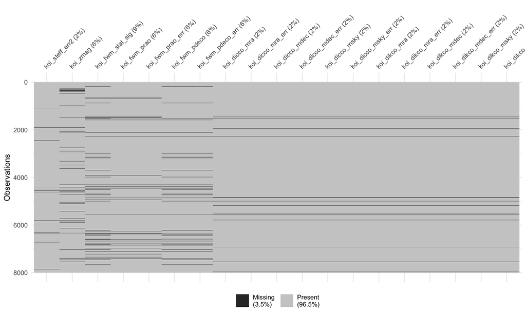

## 2.7 Final summary

```r
print(dfSummary(koi_data), method = "render")
```

Data Frame Summary

koi_data

**Dimensions**: 7998 x 122  
**Duplicates**: 0

| **No** | **Variable** | **Stats / Values** | **Freqs (% of Valid)** | **Graph** | **Valid** | **Missing** |
| --- | --- | --- | --- | --- | --- | --- |
| 1 | rowid [integer] | Mean (sd) : 4037.1 (2324.7) min ≤ med ≤ max: 1 ≤ 4038.5 ≤ 8054 IQR (CV) : 4028.5 (0.6) | 7998 distinct values |  | 7998 (100.0%) | 0 (0.0%) |
| 2 | kepid [integer] | Mean (sd) : 7694592 (2655954) min ≤ med ≤ max: 757450 ≤ 7909258 ≤ 12935144 IQR (CV) : 4326548 (0.3) | 6903 distinct values |  | 7998 (100.0%) | 0 (0.0%) |
| 3 | kepoi_name [factor] | 1. K00001.01 2. K00002.01 3. K00003.01 4. K00004.01 5. K00005.01 6. K00006.01 7. K00007.01 8. K00008.01 9. K00009.01 10. K00010.01 [ 8044 others ] | 1 ( 0.0% ) 1 ( 0.0% ) 1 ( 0.0% ) 1 ( 0.0% ) 1 ( 0.0% ) 1 ( 0.0% ) 1 ( 0.0% ) 1 ( 0.0% ) 1 ( 0.0% ) 1 ( 0.0% ) 7988 ( 99.9% ) |  | 7998 (100.0%) | 0 (0.0%) |
| 4 | kepler_name [factor] | 1. (Empty string) 2. Kepler-1 b 3. Kepler-10 b 4. Kepler-10 c 5. Kepler-100 b 6. Kepler-100 c 7. Kepler-100 d 8. Kepler-1000 b 9. Kepler-1001 b 10. Kepler-1001 c [ 2719 others ] | 5326 ( 66.6% ) 1 ( 0.0% ) 0 ( 0.0% ) 1 ( 0.0% ) 1 ( 0.0% ) 1 ( 0.0% ) 1 ( 0.0% ) 1 ( 0.0% ) 1 ( 0.0% ) 1 ( 0.0% ) 2664 ( 33.3% ) |  | 7998 (100.0%) | 0 (0.0%) |
| 5 | koi_disposition [factor] | 1. CANDIDATE 2. CONFIRMED 3. FALSE POSITIVE | 1362 ( 17.0% ) 2671 ( 33.4% ) 3965 ( 49.6% ) |  | 7998 (100.0%) | 0 (0.0%) |
| 6 | koi_vet_stat [factor] | 1. Done | 7998 ( 100.0% ) |  | 7998 (100.0%) | 0 (0.0%) |
| 7 | koi_vet_date [factor] | 1. 2017-08-31 | 7998 ( 100.0% ) |  | 7998 (100.0%) | 0 (0.0%) |
| 8 | koi_pdisposition [factor] | 1. CANDIDATE 2. FALSE POSITIVE | 4033 ( 50.4% ) 3965 ( 49.6% ) |  | 7998 (100.0%) | 0 (0.0%) |
| 9 | koi_score [numeric] | Mean (sd) : 0.5 (0.5) min ≤ med ≤ max: 0 ≤ 0.4 ≤ 1 IQR (CV) : 1 (1) | 637 distinct values |  | 7998 (100.0%) | 0 (0.0%) |
| 10 | koi_fpflag_nt [factor] | 1. 0 2. 1 | 7027 ( 87.9% ) 971 ( 12.1% ) |  | 7998 (100.0%) | 0 (0.0%) |
| 11 | koi_fpflag_ss [factor] | 1. 0 2. 1 | 5872 ( 73.4% ) 2126 ( 26.6% ) |  | 7998 (100.0%) | 0 (0.0%) |
| 12 | koi_fpflag_co [factor] | 1. 0 2. 1 | 6257 ( 78.2% ) 1741 ( 21.8% ) |  | 7998 (100.0%) | 0 (0.0%) |
| 13 | koi_fpflag_ec [factor] | 1. 0 2. 1 | 6912 ( 86.4% ) 1086 ( 13.6% ) |  | 7998 (100.0%) | 0 (0.0%) |
| 14 | koi_disp_prov [factor] | 1. q1_q17_dr25_koi | 7998 ( 100.0% ) |  | 7998 (100.0%) | 0 (0.0%) |
| 15 | koi_comment [factor] | 1. ALL_TRANS_CHASES 2. ALL_TRANS_CHASES---CENT_F 3. ALL_TRANS_CHASES---CENT_K 4. ALL_TRANS_CHASES---CENT_S 5. ALL_TRANS_CHASES---INCONS 6. ALL_TRANS_CHASES---INCONS 7. ALL_TRANS_CHASES---INCONS 8. ALL… | 3 ( 0.0% ) 14 ( 0.2% ) 1 ( 0.0% ) 3 ( 0.0% ) 1 ( 0.0% ) 13 ( 0.2% ) 2 ( 0.0% ) 1 ( 0.0% ) 2 ( 0.0% ) 1 ( 0.0% ) 7957 ( 99.5% ) |  | 7998 (100.0%) | 0 (0.0%) |
| 16 | koi_period [numeric] | Mean (sd) : 36.7 (85.4) min ≤ med ≤ max: 0.3 ≤ 7.5 ≤ 1064.3 IQR (CV) : 21 (2.3) | 7998 distinct values |  | 7998 (100.0%) | 0 (0.0%) |
| 17 | koi_period_err1 [numeric] | Mean (sd) : 0 (0) min ≤ med ≤ max: 0 ≤ 0 ≤ 0.1 IQR (CV) : 0 (5.3) | 6397 distinct values |  | 7849 (98.1%) | 149 (1.9%) |
| 18 | koi_period_err2 [numeric] | Mean (sd) : 0 (0) min ≤ med ≤ max: -0.1 ≤ 0 ≤ 0 IQR (CV) : 0 (-5.3) | 6397 distinct values |  | 7849 (98.1%) | 149 (1.9%) |
| 19 | koi_time0bk [numeric] | Mean (sd) : 157.5 (57.5) min ≤ med ≤ max: 120.6 ≤ 135.9 ≤ 1472.5 IQR (CV) : 26 (0.4) | 7978 distinct values |  | 7998 (100.0%) | 0 (0.0%) |
| 20 | koi_time0bk_err1 [numeric] | Mean (sd) : 0 (0) min ≤ med ≤ max: 0 ≤ 0 ≤ 0.6 IQR (CV) : 0 (2.7) | 2372 distinct values |  | 7849 (98.1%) | 149 (1.9%) |
| 21 | koi_time0bk_err2 [numeric] | Mean (sd) : 0 (0) min ≤ med ≤ max: -0.6 ≤ 0 ≤ 0 IQR (CV) : 0 (-2.7) | 2372 distinct values |  | 7849 (98.1%) | 149 (1.9%) |
| 22 | koi_time0 [numeric] | Mean (sd) : 2454990 (57.5) min ≤ med ≤ max: 2454954 ≤ 2454969 ≤ 2456306 IQR (CV) : 26 (0) | 6163 distinct values |  | 7998 (100.0%) | 0 (0.0%) |
| 23 | koi_time0_err1 [numeric] | Mean (sd) : 0 (0) min ≤ med ≤ max: 0 ≤ 0 ≤ 0.6 IQR (CV) : 0 (2.7) | 2372 distinct values |  | 7849 (98.1%) | 149 (1.9%) |
| 24 | koi_time0_err2 [numeric] | Mean (sd) : 0 (0) min ≤ med ≤ max: -0.6 ≤ 0 ≤ 0 IQR (CV) : 0 (-2.7) | 2372 distinct values |  | 7849 (98.1%) | 149 (1.9%) |
| 25 | koi_eccen [integer] | 1 distinct value | 0 : 7939 ( 100.0% ) |  | 7939 (99.3%) | 59 (0.7%) |
| 26 | koi_impact [numeric] | Mean (sd) : 0.6 (0.8) min ≤ med ≤ max: 0 ≤ 0.6 ≤ 25.2 IQR (CV) : 0.7 (1.3) | 1391 distinct values |  | 7939 (99.3%) | 59 (0.7%) |
| 27 | koi_impact_err1 [numeric] | Mean (sd) : 2.2 (10) min ≤ med ≤ max: 0 ≤ 0.2 ≤ 85.5 IQR (CV) : 0.3 (4.6) | 1264 distinct values |  | 7849 (98.1%) | 149 (1.9%) |
| 28 | koi_impact_err2 [numeric] | Mean (sd) : -0.3 (0.5) min ≤ med ≤ max: -18.3 ≤ -0.2 ≤ 0 IQR (CV) : 0.4 (-1.7) | 872 distinct values |  | 7849 (98.1%) | 149 (1.9%) |
| 29 | koi_duration [numeric] | Mean (sd) : 5.4 (6.4) min ≤ med ≤ max: 0.1 ≤ 3.7 ≤ 138.5 IQR (CV) : 3.5 (1.2) | 6942 distinct values |  | 7998 (100.0%) | 0 (0.0%) |
| 30 | koi_duration_err1 [numeric] | Mean (sd) : 0.3 (0.5) min ≤ med ≤ max: 0 ≤ 0.1 ≤ 13.2 IQR (CV) : 0.2 (2.1) | 2152 distinct values |  | 7849 (98.1%) | 149 (1.9%) |

[output cut: 92 more lines]

Generated by summarytools 1.1.3 ([R](https://www.r-project.org/) version 4.4.3)  
2025-05-13

## 2.8 Save data

Save Rda data of the data exploration to the data folder.

```r
saveRDS(koi_data, "data/Rdas/koi_data.Rda")
```